# Loading and Summarizing the data

White Wine Data loading and Summary analysis:

```r
WhiteWine = read.csv(file = "winequality-white.csv", header = TRUE, sep =";")
summary(WhiteWine)
```

```
##  fixed.acidity    volatile.acidity  citric.acid     residual.sugar
##  Min.   : 3.800   Min.   :0.0800   Min.   :0.0000   Min.   : 0.600
##  1st Qu.: 6.300   1st Qu.:0.2100   1st Qu.:0.2700   1st Qu.: 1.700
##  Median : 6.800   Median :0.2600   Median :0.3200   Median : 5.200
##  Mean   : 6.855   Mean   :0.2782   Mean   :0.3342   Mean   : 6.391
##  3rd Qu.: 7.300   3rd Qu.:0.3200   3rd Qu.:0.3900   3rd Qu.: 9.900
##  Max.   :14.200   Max.   :1.1000   Max.   :1.6600   Max.   :65.800
##    chlorides       free.sulfur.dioxide total.sulfur.dioxide
##  Min.   :0.00900   Min.   :  2.00      Min.   :  9.0
##  1st Qu.:0.03600   1st Qu.: 23.00      1st Qu.:108.0
##  Median :0.04300   Median : 34.00      Median :134.0
##  Mean   :0.04577   Mean   : 35.31      Mean   :138.4
##  3rd Qu.:0.05000   3rd Qu.: 46.00      3rd Qu.:167.0
##  Max.   :0.34600   Max.   :289.00      Max.   :440.0
##     density             pH          sulphates         alcohol
##  Min.   :0.9871   Min.   :2.720   Min.   :0.2200   Min.   : 8.00
##  1st Qu.:0.9917   1st Qu.:3.090   1st Qu.:0.4100   1st Qu.: 9.50
##  Median :0.9937   Median :3.180   Median :0.4700   Median :10.40
##  Mean   :0.9940   Mean   :3.188   Mean   :0.4898   Mean   :10.51
##  3rd Qu.:0.9961   3rd Qu.:3.280   3rd Qu.:0.5500   3rd Qu.:11.40
##  Max.   :1.0390   Max.   :3.820   Max.   :1.0800   Max.   :14.20
##     quality
##  Min.   :3.000
##  1st Qu.:5.000
##  Median :6.000
##  Mean   :5.878
##  3rd Qu.:6.000
##  Max.   :9.000
```

Initial analysis of summary statistics reveal certain outliers for Residual Sugar, free sulfur dioxide etc. Lets look at the pairwise plot below.

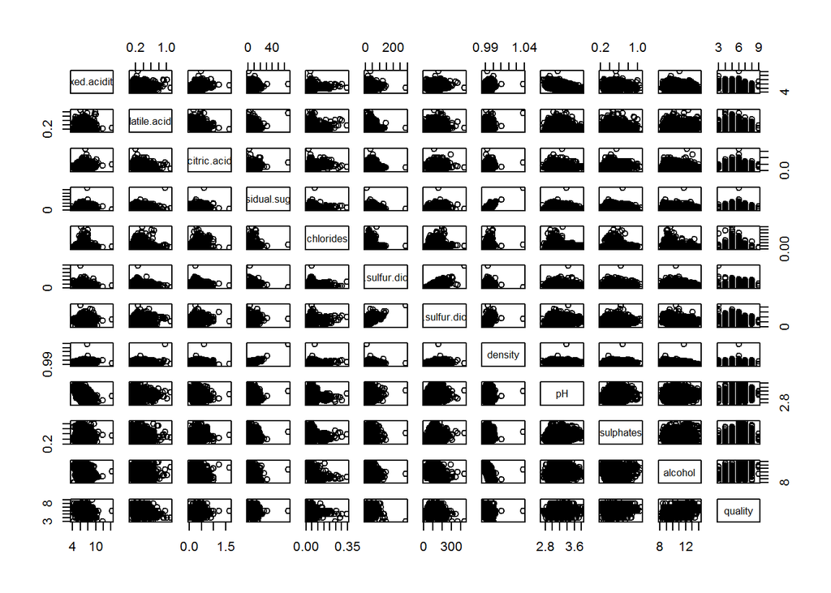

```r
pairs(WhiteWine[])
```

The pairwise plot though not clear points to the direction that most of the data looks like a blob except for few outliers.

Red wine data loading and Summary Analysis:

```r
RedWine = read.csv(file = "winequality-red.csv", header = TRUE, sep =";")
summary(RedWine)
```

```
##  fixed.acidity   volatile.acidity  citric.acid    residual.sugar
##  Min.   : 4.60   Min.   :0.1200   Min.   :0.000   Min.   : 0.900
##  1st Qu.: 7.10   1st Qu.:0.3900   1st Qu.:0.090   1st Qu.: 1.900
##  Median : 7.90   Median :0.5200   Median :0.260   Median : 2.200
##  Mean   : 8.32   Mean   :0.5278   Mean   :0.271   Mean   : 2.539
##  3rd Qu.: 9.20   3rd Qu.:0.6400   3rd Qu.:0.420   3rd Qu.: 2.600
##  Max.   :15.90   Max.   :1.5800   Max.   :1.000   Max.   :15.500
##    chlorides       free.sulfur.dioxide total.sulfur.dioxide
##  Min.   :0.01200   Min.   : 1.00       Min.   :  6.00
##  1st Qu.:0.07000   1st Qu.: 7.00       1st Qu.: 22.00
##  Median :0.07900   Median :14.00       Median : 38.00
##  Mean   :0.08747   Mean   :15.87       Mean   : 46.47
##  3rd Qu.:0.09000   3rd Qu.:21.00       3rd Qu.: 62.00
##  Max.   :0.61100   Max.   :72.00       Max.   :289.00
##     density             pH          sulphates         alcohol
##  Min.   :0.9901   Min.   :2.740   Min.   :0.3300   Min.   : 8.40
##  1st Qu.:0.9956   1st Qu.:3.210   1st Qu.:0.5500   1st Qu.: 9.50
##  Median :0.9968   Median :3.310   Median :0.6200   Median :10.20
##  Mean   :0.9967   Mean   :3.311   Mean   :0.6581   Mean   :10.42
##  3rd Qu.:0.9978   3rd Qu.:3.400   3rd Qu.:0.7300   3rd Qu.:11.10
##  Max.   :1.0037   Max.   :4.010   Max.   :2.0000   Max.   :14.90
##     quality
##  Min.   :3.000
##  1st Qu.:5.000
##  Median :6.000
##  Mean   :5.636
##  3rd Qu.:6.000
##  Max.   :8.000
```

The range of values and maximum values for residual sugar, free sulfur dioxide is different from white wine hinting at different types of concentration in the wines depending on the wine type

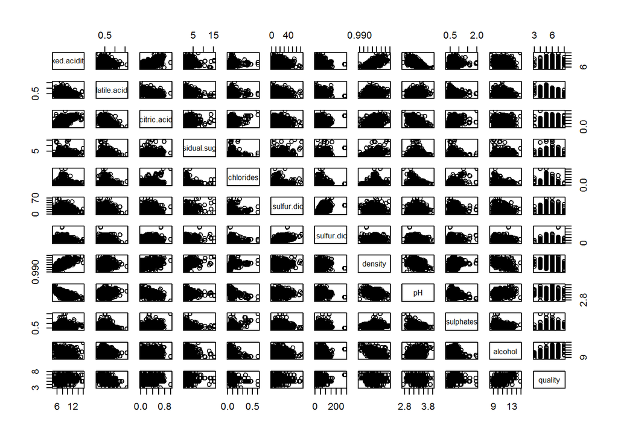

```r
pairs(RedWine[])
```

The pairwise plot for Red wine also reveals the same thing, most part of the data is just a blob with few outliers.

Lets try to understand if any predictor variables is related to the outcome. Performing pearson correlation.

```r
Cor_pearson <- cor(WhiteWine,method="pearson")
Cor_pearson
```

```
##                      fixed.acidity volatile.acidity  citric.acid
## fixed.acidity           1.00000000      -0.02269729  0.289180698
## volatile.acidity       -0.02269729       1.00000000 -0.149471811
## citric.acid             0.28918070      -0.14947181  1.000000000
## residual.sugar          0.08902070       0.06428606  0.094211624
## chlorides               0.02308564       0.07051157  0.114364448
## free.sulfur.dioxide    -0.04939586      -0.09701194  0.094077221
## total.sulfur.dioxide    0.09106976       0.08926050  0.121130798
## density                 0.26533101       0.02711385  0.149502571
## pH                     -0.42585829      -0.03191537 -0.163748211
## sulphates              -0.01714299      -0.03572815  0.062330940
## alcohol                -0.12088112       0.06771794 -0.075728730
## quality                -0.11366283      -0.19472297 -0.009209091
##                      residual.sugar   chlorides free.sulfur.dioxide
## fixed.acidity            0.08902070  0.02308564       -0.0493958591
## volatile.acidity         0.06428606  0.07051157       -0.0970119393
## citric.acid              0.09421162  0.11436445        0.0940772210
## residual.sugar           1.00000000  0.08868454        0.2990983537
## chlorides                0.08868454  1.00000000        0.1013923521
## free.sulfur.dioxide      0.29909835  0.10139235        1.0000000000
## total.sulfur.dioxide     0.40143931  0.19891030        0.6155009650
## density                  0.83896645  0.25721132        0.2942104109
## pH                      -0.19413345 -0.09043946       -0.0006177961
## sulphates               -0.02666437  0.01676288        0.0592172458
## alcohol                 -0.45063122 -0.36018871       -0.2501039415
## quality                 -0.09757683 -0.20993441        0.0081580671
##                      total.sulfur.dioxide     density            pH
## fixed.acidity                 0.091069756  0.26533101 -0.4258582910
## volatile.acidity              0.089260504  0.02711385 -0.0319153683
## citric.acid                   0.121130798  0.14950257 -0.1637482114
## residual.sugar                0.401439311  0.83896645 -0.1941334540
## chlorides                     0.198910300  0.25721132 -0.0904394560
## free.sulfur.dioxide           0.615500965  0.29421041 -0.0006177961
## total.sulfur.dioxide          1.000000000  0.52988132  0.0023209718
## density                       0.529881324  1.00000000 -0.0935914935
## pH                            0.002320972 -0.09359149  1.0000000000
## sulphates                     0.134562367  0.07449315  0.1559514973
## alcohol                      -0.448892102 -0.78013762  0.1214320987
## quality                      -0.174737218 -0.30712331  0.0994272457
##                        sulphates     alcohol      quality
## fixed.acidity        -0.01714299 -0.12088112 -0.113662831
## volatile.acidity     -0.03572815  0.06771794 -0.194722969
## citric.acid           0.06233094 -0.07572873 -0.009209091
## residual.sugar       -0.02666437 -0.45063122 -0.097576829
## chlorides             0.01676288 -0.36018871 -0.209934411
## free.sulfur.dioxide   0.05921725 -0.25010394  0.008158067
## total.sulfur.dioxide  0.13456237 -0.44889210 -0.174737218
## density               0.07449315 -0.78013762 -0.307123313
## pH                    0.15595150  0.12143210  0.099427246
## sulphates             1.00000000 -0.01743277  0.053677877
## alcohol              -0.01743277  1.00000000  0.435574715
## quality               0.05367788  0.43557472  1.000000000
```

Among all the variables Alcohol has the highest correlation with the outcome variable in case of white wine. The correlation value of 0.43 is considered moderate correlation. Let us try to keep this variable in our analysis.

```r
Cor_pearson <- cor(RedWine,method="pearson")
Cor_pearson
```

```
##                      fixed.acidity volatile.acidity citric.acid
## fixed.acidity           1.00000000     -0.256130895  0.67170343
## volatile.acidity       -0.25613089      1.000000000 -0.55249568
## citric.acid             0.67170343     -0.552495685  1.00000000
## residual.sugar          0.11477672      0.001917882  0.14357716
## chlorides               0.09370519      0.061297772  0.20382291
## free.sulfur.dioxide    -0.15379419     -0.010503827 -0.06097813
## total.sulfur.dioxide   -0.11318144      0.076470005  0.03553302
## density                 0.66804729      0.022026232  0.36494718
## pH                     -0.68297819      0.234937294 -0.54190414
## sulphates               0.18300566     -0.260986685  0.31277004
## alcohol                -0.06166827     -0.202288027  0.10990325
## quality                 0.12405165     -0.390557780  0.22637251
##                      residual.sugar    chlorides free.sulfur.dioxide
## fixed.acidity           0.114776724  0.093705186        -0.153794193
## volatile.acidity        0.001917882  0.061297772        -0.010503827
## citric.acid             0.143577162  0.203822914        -0.060978129
## residual.sugar          1.000000000  0.055609535         0.187048995
## chlorides               0.055609535  1.000000000         0.005562147
## free.sulfur.dioxide     0.187048995  0.005562147         1.000000000
## total.sulfur.dioxide    0.203027882  0.047400468         0.667666450
## density                 0.355283371  0.200632327        -0.021945831
## pH                     -0.085652422 -0.265026131         0.070377499
## sulphates               0.005527121  0.371260481         0.051657572
## alcohol                 0.042075437 -0.221140545        -0.069408354
## quality                 0.013731637 -0.128906560        -0.050656057
##                      total.sulfur.dioxide     density          pH
## fixed.acidity                 -0.11318144  0.66804729 -0.68297819
## volatile.acidity               0.07647000  0.02202623  0.23493729
## citric.acid                    0.03553302  0.36494718 -0.54190414
## residual.sugar                 0.20302788  0.35528337 -0.08565242
## chlorides                      0.04740047  0.20063233 -0.26502613
## free.sulfur.dioxide            0.66766645 -0.02194583  0.07037750
## total.sulfur.dioxide           1.00000000  0.07126948 -0.06649456
## density                        0.07126948  1.00000000 -0.34169933
## pH                            -0.06649456 -0.34169933  1.00000000
## sulphates                      0.04294684  0.14850641 -0.19664760
## alcohol                       -0.20565394 -0.49617977  0.20563251
## quality                       -0.18510029 -0.17491923 -0.05773139
##                         sulphates     alcohol     quality
## fixed.acidity         0.183005664 -0.06166827  0.12405165
## volatile.acidity     -0.260986685 -0.20228803 -0.39055778
## citric.acid           0.312770044  0.10990325  0.22637251
## residual.sugar        0.005527121  0.04207544  0.01373164
## chlorides             0.371260481 -0.22114054 -0.12890656
## free.sulfur.dioxide   0.051657572 -0.06940835 -0.05065606
## total.sulfur.dioxide  0.042946836 -0.20565394 -0.18510029
## density               0.148506412 -0.49617977 -0.17491923
## pH                   -0.196647602  0.20563251 -0.05773139
## sulphates             1.000000000  0.09359475  0.25139708
## alcohol               0.093594750  1.00000000  0.47616632
## quality               0.251397079  0.47616632  1.00000000
```

Among all the variables Alcohol has the highest correlation with the outcome variable in case of Red wine. The correlation value of 0.47 is considered moderate correlation. Let us try to keep this variable in our analysis.

# Choose optimal models by exhaustive, forward and backward selection

WhiteWine subset selection:

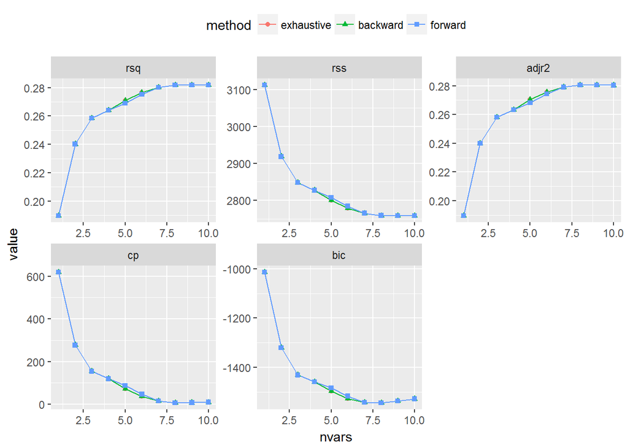

```r
summaryMetrics <- NULL
whichAll <- list()
for ( myMthd in c("exhaustive", "backward", "forward") ) {
  rsRes <- regsubsets(quality~.,WhiteWine,method=myMthd,nvmax=10)
  summRes <- summary(rsRes)
  whichAll[[myMthd]] <- summRes$which
  for ( metricName in c("rsq","rss","adjr2","cp","bic") ) {
    summaryMetrics <- rbind(summaryMetrics,
      data.frame(method=myMthd,metric=metricName,
                nvars=1:length(summRes[[metricName]]),
                value=summRes[[metricName]]))
  }
}
ggplot(summaryMetrics,aes(x=nvars,y=value,shape=method,colour=method)) + geom_path() + geom_point() + facet_wrap(~metric,scales="free") +   theme(legend.position="top")
```

We can see that, all methods came up with models of very comparable performance by every associated metric. The number of optimal variables are 7, from 8the variable the reduction in error is very low or negligible.

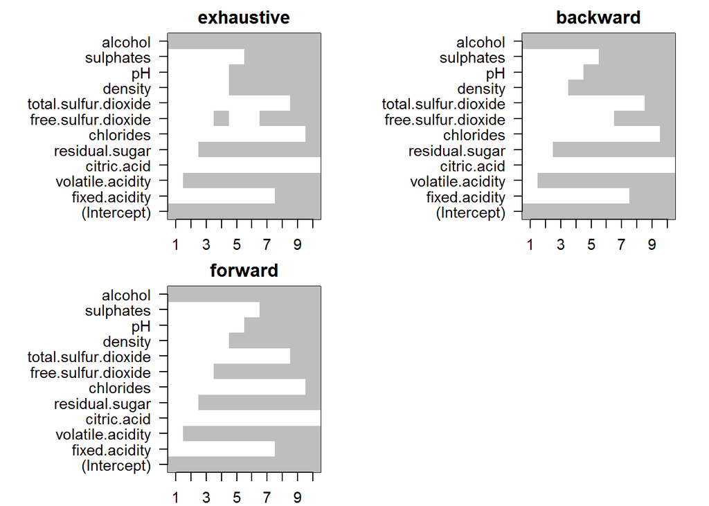

```r
old.par <- par(mfrow=c(2,2),ps=13,mar=c(2,10,2,2))
for ( myMthd in names(whichAll) ) {
  image(1:nrow(whichAll[[myMthd]]),
        1:ncol(whichAll[[myMthd]]),
        whichAll[[myMthd]],xlab="N(vars)",ylab="",
        xaxt="n",yaxt="n",breaks=c(-0.5,0.5,1.5),
        col=c("white","gray"),main=myMthd)
  axis(1,1:nrow(whichAll[[myMthd]]),rownames(whichAll[[myMthd]]))
  axis(2,1:ncol(whichAll[[myMthd]]),colnames(whichAll[[myMthd]]),las=2)
}
```

In case of white wine the 7 variables selected by exhaustive, backward and forward selection methods are volatile acidity, residual sugar, free sulfur dioxide, density, pH, sulphates and alcohol.

Red wine subset selection:

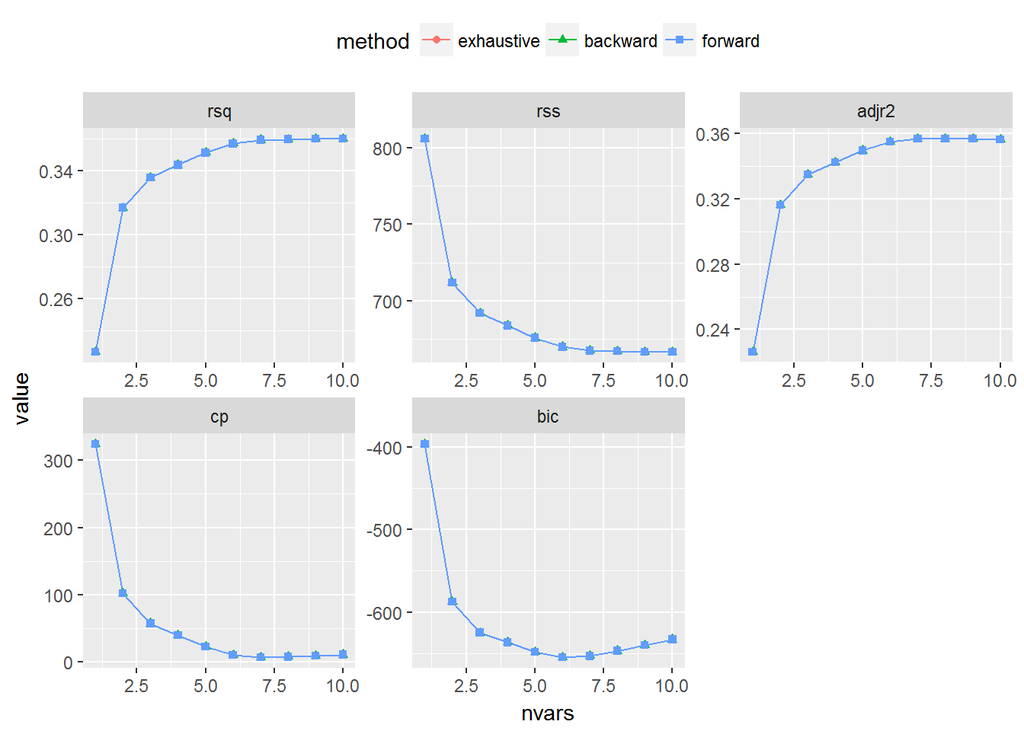

```r
summaryMetrics <- NULL
whichAll <- list()
for ( myMthd in c("exhaustive", "backward", "forward") ) {
  rsRes <- regsubsets(quality~.,RedWine,method=myMthd,nvmax=10)
  summRes <- summary(rsRes)
  whichAll[[myMthd]] <- summRes$which
  for ( metricName in c("rsq","rss","adjr2","cp","bic") ) {
    summaryMetrics <- rbind(summaryMetrics,
      data.frame(method=myMthd,metric=metricName,
                nvars=1:length(summRes[[metricName]]),
                value=summRes[[metricName]]))
  }
}
ggplot(summaryMetrics,aes(x=nvars,y=value,shape=method,colour=method)) + geom_path() + geom_point() + facet_wrap(~metric,scales="free") +   theme(legend.position="top")
```

We can see that, all methods came up with models of very comparable performance by every associated metric. The number of optimal variables are 6, from 7th variable the reduction in error is very low or negligible.

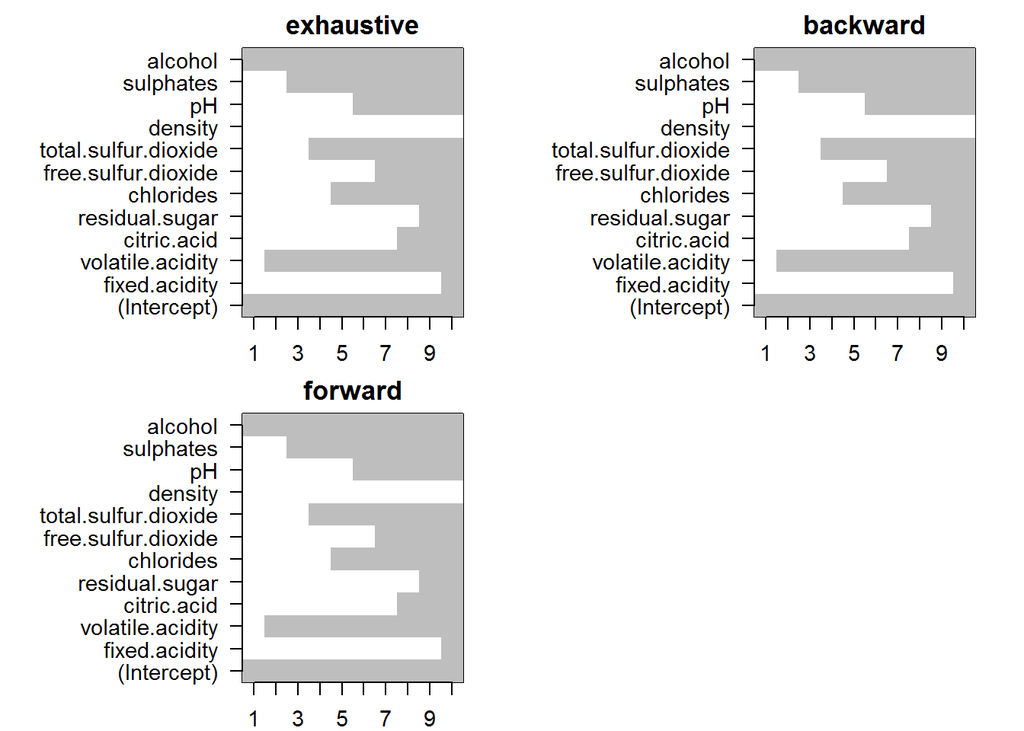

```r
old.par <- par(mfrow=c(2,2),ps=13,mar=c(2,10,2,2))
for ( myMthd in names(whichAll) ) {
  image(1:nrow(whichAll[[myMthd]]),
        1:ncol(whichAll[[myMthd]]),
        whichAll[[myMthd]],xlab="N(vars)",ylab="",
        xaxt="n",yaxt="n",breaks=c(-0.5,0.5,1.5),
        col=c("white","gray"),main=myMthd)
  axis(1,1:nrow(whichAll[[myMthd]]),rownames(whichAll[[myMthd]]))
  axis(2,1:ncol(whichAll[[myMthd]]),colnames(whichAll[[myMthd]]),las=2)
}
```

In case of Red wine the 6 variables selected by exhaustive, backward and forward selection methods are volatile acidity, chlorides, total sulfur dioxide, pH, sulphates and alcohol.

Good point to observe here is that in case of white wine and red wine the subset parameters are different. Meaning that the parameters that influence quality of white wine are different from parameters that influence quality of red wine.

# Optimal model by cross-validation

Cross Validation on White wine:

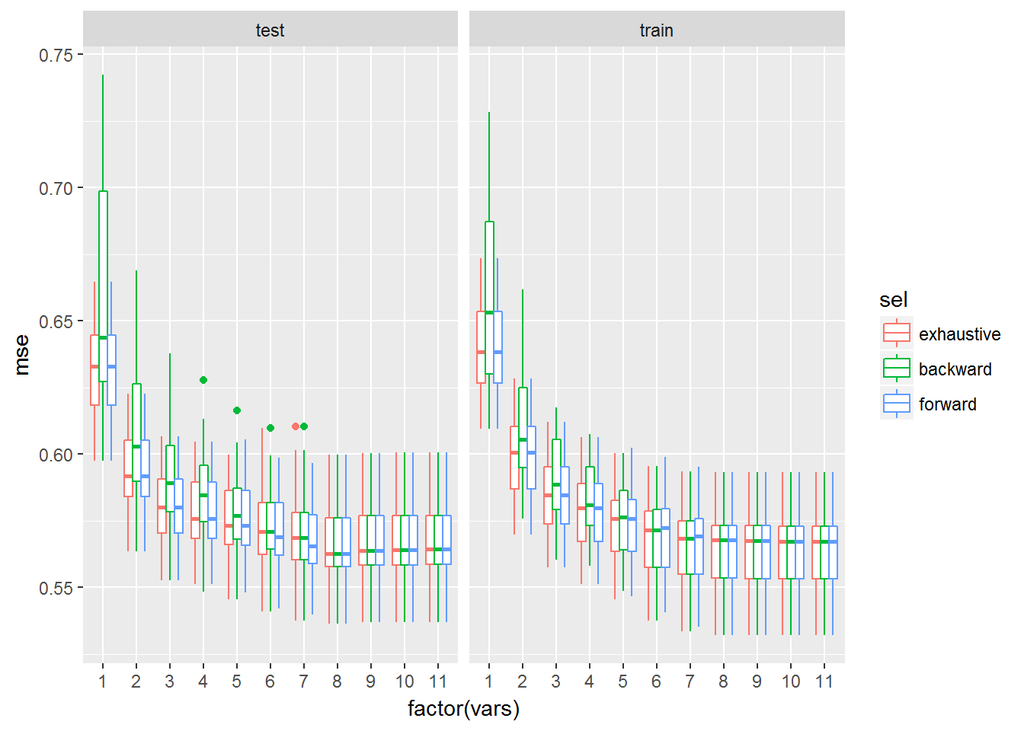

```r
predict.regsubsets =function (object ,newdata ,id ,...){
form=as.formula (object$call [[2]])
mat=model.matrix (form ,newdata )
coefi =coef(object ,id=id)
xvars =names (coefi )
mat[,xvars ]%*% coefi
}

dfTmp <- NULL
whichSum <- array(0,dim=c(11,12,3),
  dimnames=list(NULL,colnames(model.matrix(quality~.,WhiteWine)),
      c("exhaustive", "backward", "forward")))
nTries <- 30
for ( iTry in 1:nTries ) {
  bTrain <- sample(rep(c(TRUE,FALSE),length.out=nrow(WhiteWine)))
  # Try each method available in regsubsets
  # to select the best model of each size:
  for ( jSelect in c("exhaustive", "backward", "forward") ) {
    rsTrain <- regsubsets(quality~.,WhiteWine[bTrain,],nvmax=11,method=jSelect)
    # Add up variable selections:
    whichSum[,,jSelect] <- whichSum[,,jSelect] + summary(rsTrain)$which
    # Calculate test error for each set of variables
    # using predict.regsubsets implemented above:
    for ( kVarSet in 1:11 ) {
      # make predictions:
      testPred <- predict(rsTrain,WhiteWine[!bTrain,],id=kVarSet)
      # calculate MSE:
      mseTest <- mean((testPred-WhiteWine[!bTrain,"quality"])^2)
      # add to data.frame for future plotting:
      dfTmp <- rbind(dfTmp,data.frame(sim=iTry,sel=jSelect,vars=kVarSet,
      mse=c(mseTest,summary(rsTrain)$rss[kVarSet]/sum(bTrain)),trainTest=c("test","train")))
    }
  }
}
# plot MSEs by training/test, number of
# variables and selection method:
ggplot(dfTmp,aes(x=factor(vars),y=mse,colour=sel)) + geom_boxplot()+facet_wrap(~trainTest)
```

In case of cross validation approach the training mse is around 0.56 for 7 variables. The test error is 0.58

Cross validation for Red Wine:

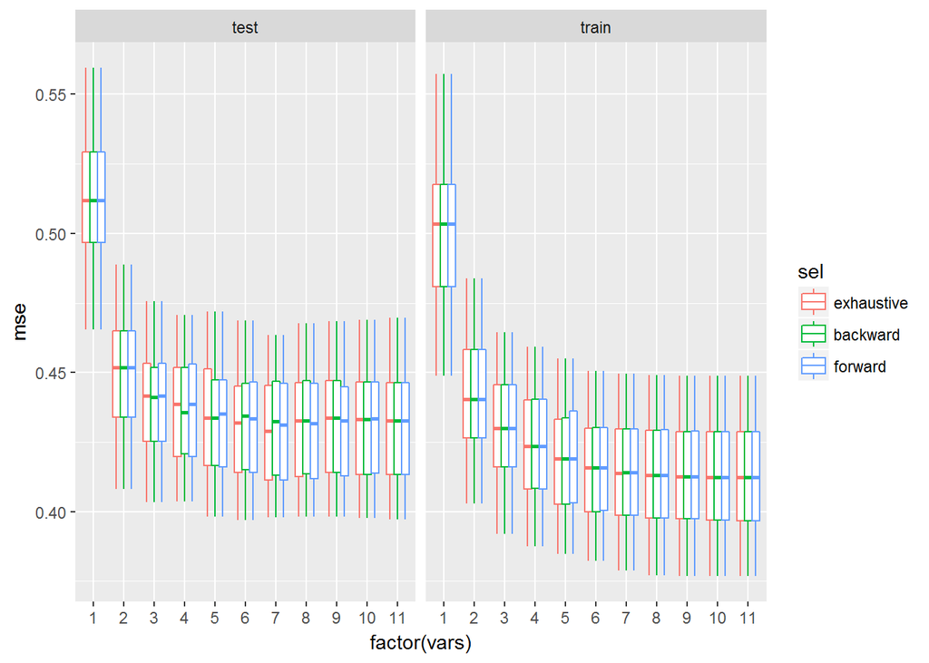

```r
dfTmp <- NULL
whichSum <- array(0,dim=c(11,12,3),
  dimnames=list(NULL,colnames(model.matrix(quality~.,RedWine)),
      c("exhaustive", "backward", "forward")))
nTries <- 30
for ( iTry in 1:nTries ) {
  bTrain <- sample(rep(c(TRUE,FALSE),length.out=nrow(RedWine)))
  # Try each method available in regsubsets
  # to select the best model of each size:
  for ( jSelect in c("exhaustive", "backward", "forward") ) {
    rsTrain <- regsubsets(quality~.,RedWine[bTrain,],nvmax=11,method=jSelect)
    # Add up variable selections:
    whichSum[,,jSelect] <- whichSum[,,jSelect] + summary(rsTrain)$which
    # Calculate test error for each set of variables
    # using predict.regsubsets implemented above:
    for ( kVarSet in 1:11 ) {
      # make predictions:
      testPred <- predict(rsTrain,RedWine[!bTrain,],id=kVarSet)
      # calculate MSE:
      mseTest <- mean((testPred-RedWine[!bTrain,"quality"])^2)
      # add to data.frame for future plotting:
      dfTmp <- rbind(dfTmp,data.frame(sim=iTry,sel=jSelect,vars=kVarSet,
      mse=c(mseTest,summary(rsTrain)$rss[kVarSet]/sum(bTrain)),trainTest=c("test","train")))
    }
  }
}
# plot MSEs by training/test, number of
# variables and selection method:
ggplot(dfTmp,aes(x=factor(vars),y=mse,colour=sel)) + geom_boxplot()+facet_wrap(~trainTest)
```

In case of cross validation approach the training mse is around 0.42 for 6 variables. The test error is 0.43

# Lasso/Ridge

Ridge regression for White wine:

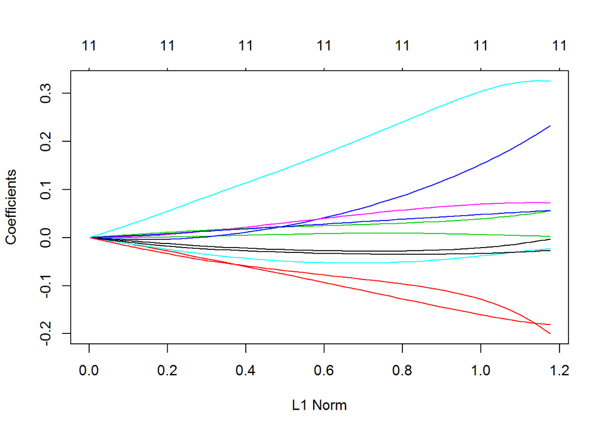

```r
x <- model.matrix(quality~.,WhiteWine)[,-1]
y <- WhiteWine[,"quality"]
ridgeRes <- glmnet(scale(x),y,alpha=0)
plot(ridgeRes)
```

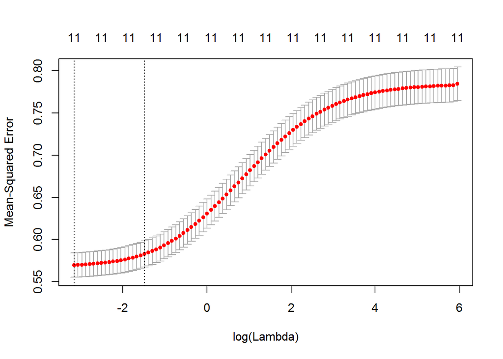

```r
cvRidgeRes <- cv.glmnet(scale(x),y,alpha=0)
plot(cvRidgeRes)
```

Output of glmnet illustrates change in the contributions of each of the predictors as amount of shrinkage changes. The contribution variables are observed for some range of shrinkage changes.

Output of cv.glmnet shows averages and variabilities of MSE in cross-validation across different levels of regularization. lambda.min field indicates values of ?? (0.042) at which the lowest average MSE has been achieved, lambda.1se shows larger ?? (more regularization) that has MSE 1SD (of cross-validation) higher than the minimum - this is an often recommended ?? (0.225) to use under the idea that it will be less susceptible to overfit.

The below are coefficients for ridge regression for the fields lambda.min and lambda.lse

```r
cvRidgeRes$lambda.min
```

```
## [1] 0.04233298
```

```r
predict(ridgeRes,type="coefficients",s=cvRidgeRes$lambda.min)
```

```
## 12 x 1 sparse Matrix of class "dgCMatrix"
##                                 1
## (Intercept)           5.877909351
## fixed.acidity        -0.004574641
## volatile.acidity     -0.180043857
## citric.acid           0.002826352
## residual.sugar        0.225992500
## chlorides            -0.023603324
## free.sulfur.dioxide   0.072200358
## total.sulfur.dioxide -0.027343604
## density              -0.192653624
## pH                    0.053876125
## sulphates             0.055639515
## alcohol               0.325315748
```

```r
cvRidgeRes$lambda.1se
```

```
## [1] 0.2259184
```

```r
predict(ridgeRes,type="coefficients",s=cvRidgeRes$lambda.1se)
```

```
## 12 x 1 sparse Matrix of class "dgCMatrix"
##                                 1
## (Intercept)           5.877909351
## fixed.acidity        -0.025926876
## volatile.acidity     -0.143028051
## citric.acid           0.008105295
## residual.sugar        0.114604712
## chlorides            -0.046218610
## free.sulfur.dioxide   0.063895796
## total.sulfur.dioxide -0.034629946
## density              -0.107827290
## pH                    0.033640519
## sulphates             0.042790101
## alcohol               0.271608441
```

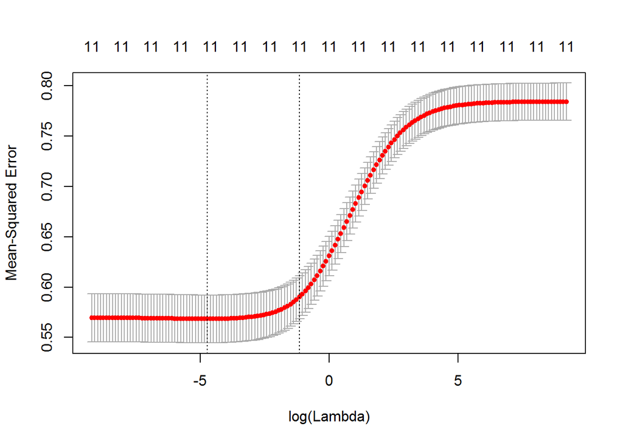

```r
# and with lambda's other than default:
cvRidgeRes <- cv.glmnet(x,y,alpha=0,lambda=10^((-80:80)/20))
plot(cvRidgeRes)
```

```r
ridgeResScaled <- glmnet(scale(x),y,alpha=0)
cvRidgeResScaled <- cv.glmnet(scale(x),y,alpha=0)
predict(ridgeResScaled,type="coefficients",s=cvRidgeResScaled$lambda.1se)
```

```
## 12 x 1 sparse Matrix of class "dgCMatrix"
##                                 1
## (Intercept)           5.877909351
## fixed.acidity        -0.026981277
## volatile.acidity     -0.136245447
## citric.acid           0.008592968
## residual.sugar        0.102162221
## chlorides            -0.048529862
## free.sulfur.dioxide   0.061193399
## total.sulfur.dioxide -0.034855954
## density              -0.102354959
## pH                    0.032038381
## sulphates             0.040853113
## alcohol               0.258216519
```

Below is the Lasso regression for white wine:

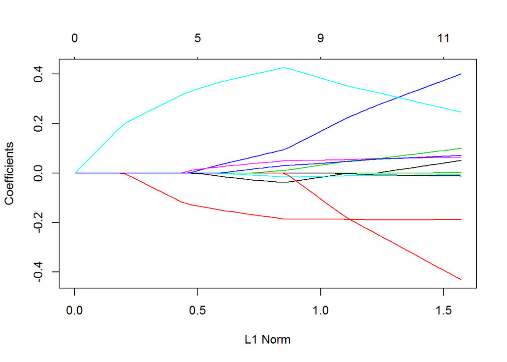

```r
lassoRes <- glmnet(scale(x),y,alpha=1)
plot(lassoRes)
```

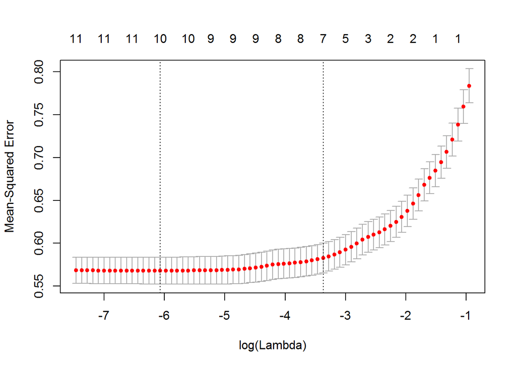

```r
cvLassoRes <- cv.glmnet(scale(x),y,alpha=1)
plot(cvLassoRes)
```

Output of glmnet illustrates change in the contributions of each of the predictors as amount of shrinkage changes. Unline Ridge regression, the contribution variables are not observed for some range of shrinkage changes. For example the blue line indicates that the coefficient is 0 upto L1 norm is 0.5. Similarly for other variables.

```r
predict(lassoRes,type="coefficients",s=cvLassoRes$lambda.1se)
```

```
## 12 x 1 sparse Matrix of class "dgCMatrix"
##                                 1
## (Intercept)           5.877909351
## fixed.acidity        -0.025674777
## volatile.acidity     -0.164641376
## citric.acid           .
## residual.sugar        0.059329017
## chlorides            -0.007017241
## free.sulfur.dioxide   0.036085368
## total.sulfur.dioxide  .
## density               .
## pH                    .
## sulphates             0.013287440
## alcohol               0.392930961
```

```r
predict(lassoRes,type="coefficients",s=cvLassoRes$lambda.min)
```

```
## 12 x 1 sparse Matrix of class "dgCMatrix"
##                                 1
## (Intercept)           5.877909351
## fixed.acidity         0.028006803
## volatile.acidity     -0.189011042
## citric.acid           .
## residual.sugar        0.343087891
## chlorides            -0.008280781
## free.sulfur.dioxide   0.061337225
## total.sulfur.dioxide -0.010018694
## density              -0.346927883
## pH                    0.080730092
## sulphates             0.064142977
## alcohol               0.282764435
```

The coefficients corresponding to lowest average MSE is achieved when the S is set to lambda.min field. The coefficient of citric acid is 0. When S is set to lambda.1se field the coefficient of citric acid, total sulfur dioxide and density is equal to 0.

Ridge regression for Red wine:

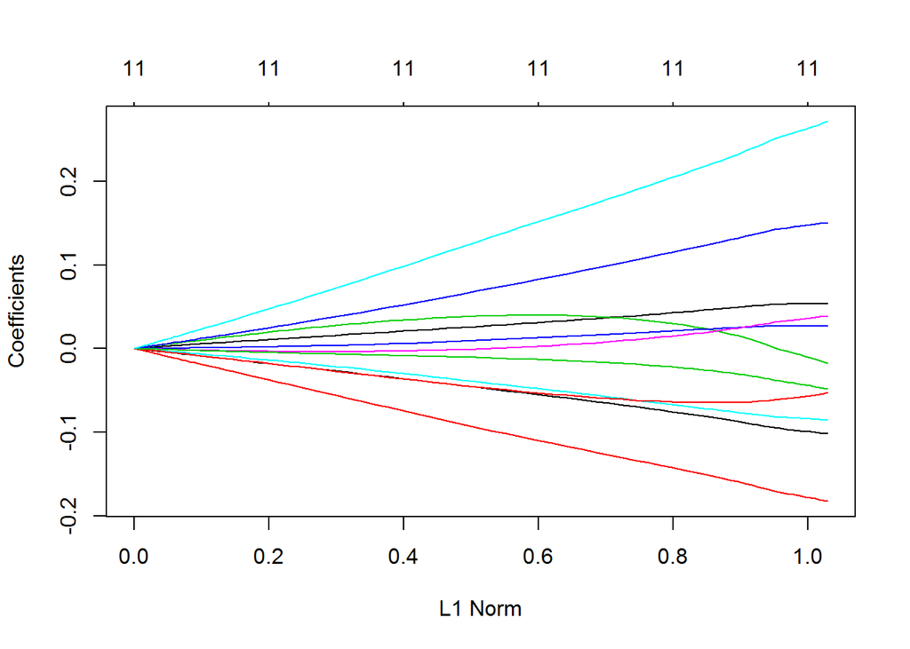

```r
x <- model.matrix(quality~.,RedWine)[,-1]
y <- RedWine[,"quality"]
ridgeRes <- glmnet(scale(x),y,alpha=0)
plot(ridgeRes)
```

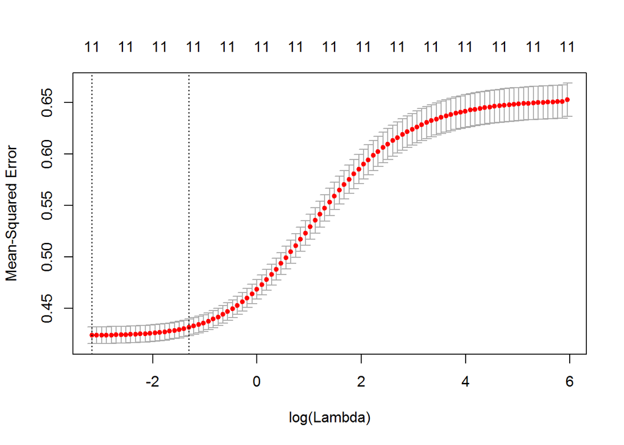

```r
cvRidgeRes <- cv.glmnet(scale(x),y,alpha=0)
plot(cvRidgeRes)
```

Output of glmnet illustrates change in the contributions of each of the predictors as amount of shrinkage changes. The contribution variables are observed for range of shrinkage changes.

The below are coefficients for ridge regression for the fields lambda.min and lambda.lse

```r
cvRidgeRes$lambda.min
```

```
## [1] 0.04218973
```

```r
predict(ridgeRes,type="coefficients",s=cvRidgeRes$lambda.min)
```

```
## 12 x 1 sparse Matrix of class "dgCMatrix"
##                                1
## (Intercept)           5.63602251
## fixed.acidity         0.05348478
## volatile.acidity     -0.18158331
## citric.acid          -0.01593318
## residual.sugar        0.02706594
## chlorides            -0.08511045
## free.sulfur.dioxide   0.03851676
## total.sulfur.dioxide -0.10117062
## density              -0.05352363
## pH                   -0.04748817
## sulphates             0.15014626
## alcohol               0.26981622
```

```r
cvRidgeRes$lambda.1se
```

```
## [1] 0.2711987
```

```r
predict(ridgeRes,type="coefficients",s=cvRidgeRes$lambda.1se)
```

```
## 12 x 1 sparse Matrix of class "dgCMatrix"
##                                1
## (Intercept)           5.63602251
## fixed.acidity         0.04496246
## volatile.acidity     -0.14753638
## citric.acid           0.02643463
## residual.sugar        0.02261511
## chlorides            -0.06988126
## free.sulfur.dioxide   0.01784719
## total.sulfur.dioxide -0.07903624
## density              -0.06439534
## pH                   -0.02405663
## sulphates             0.12065729
## alcohol               0.21321677
```

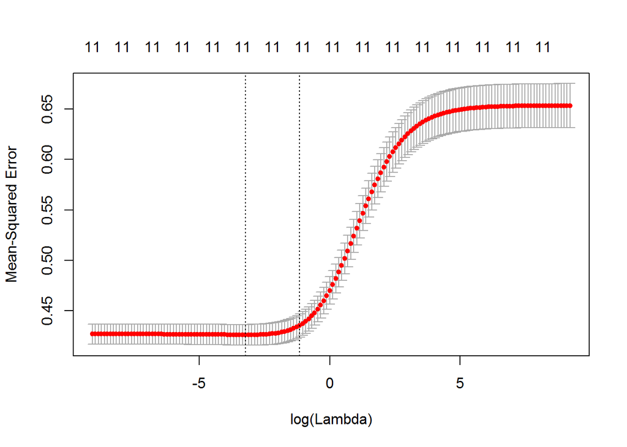

```r
# and with lambda's other than default:
cvRidgeRes <- cv.glmnet(x,y,alpha=0,lambda=10^((-80:80)/20))
plot(cvRidgeRes)
```

```r
ridgeResScaled <- glmnet(scale(x),y,alpha=0)
cvRidgeResScaled <- cv.glmnet(scale(x),y,alpha=0)
predict(ridgeResScaled,type="coefficients",s=cvRidgeResScaled$lambda.1se)
```

```
## 12 x 1 sparse Matrix of class "dgCMatrix"
##                                1
## (Intercept)           5.63602251
## fixed.acidity         0.04284269
## volatile.acidity     -0.14222365
## citric.acid           0.03031396
## residual.sugar        0.02122682
## chlorides            -0.06679285
## free.sulfur.dioxide   0.01503461
## total.sulfur.dioxide -0.07535091
## density              -0.06363294
## pH                   -0.02178185
## sulphates             0.11516132
## alcohol               0.20438810
```

Lasso Regression for Red Wine:

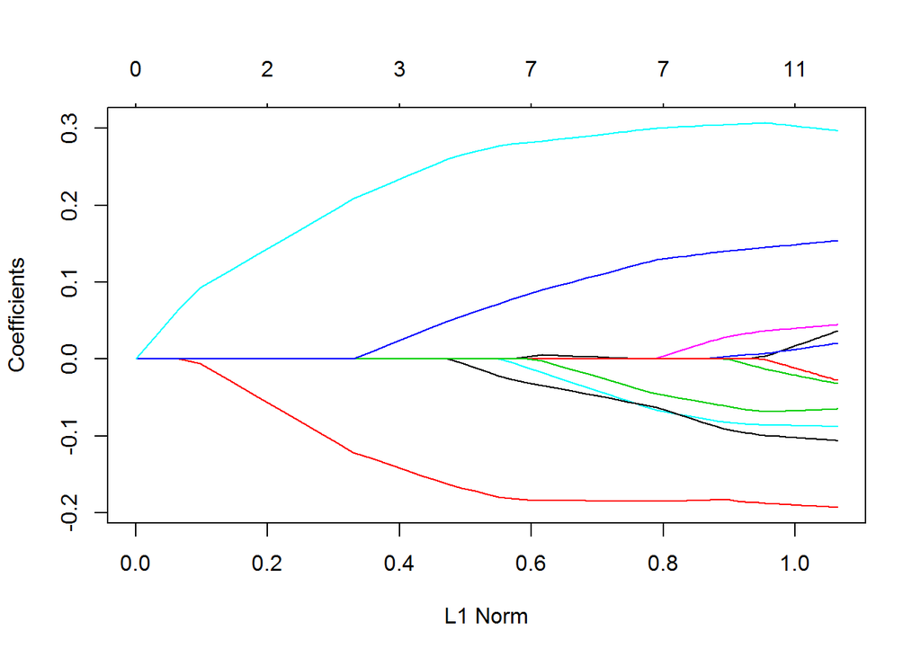

```r
lassoRes <- glmnet(scale(x),y,alpha=1)
plot(lassoRes)
```

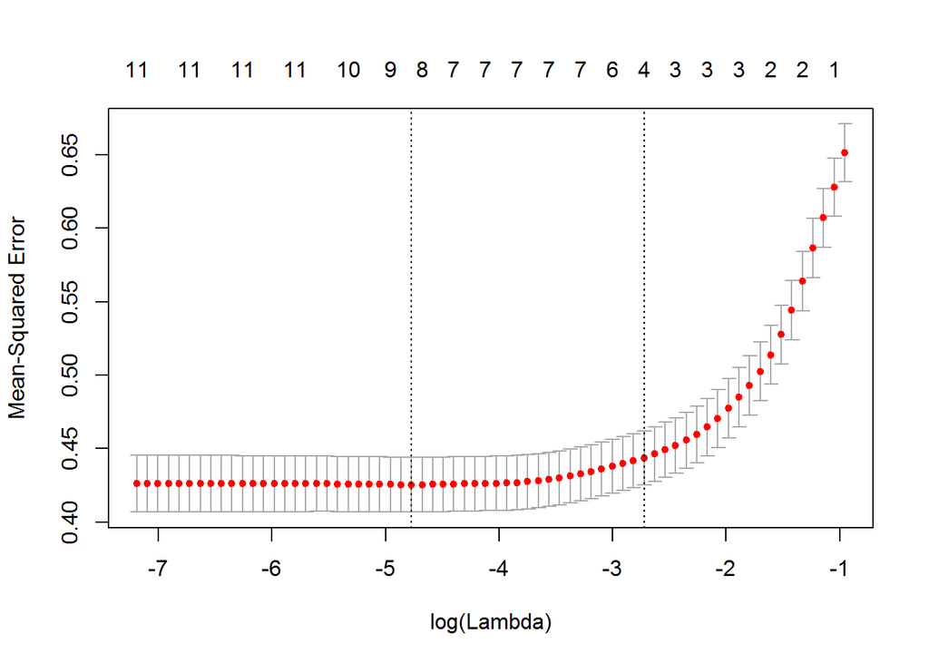

```r
cvLassoRes <- cv.glmnet(scale(x),y,alpha=1)
plot(cvLassoRes)
```

Output of glmnet illustrates change in the contributions of each of the predictors as amount of shrinkage changes. Unlike Ridge regression, the contribution variables are not observed for some range of shrinkage changes. For example the green line indicates that the coefficient is 0 upto L1 norm is 0.6. Similarly for other variables.

```r
predict(lassoRes,type="coefficients",s=cvLassoRes$lambda.1se)
```

```
## 12 x 1 sparse Matrix of class "dgCMatrix"
##                                1
## (Intercept)           5.63602251
## fixed.acidity         .
## volatile.acidity     -0.17572220
## citric.acid           .
## residual.sugar        .
## chlorides             .
## free.sulfur.dioxide   .
## total.sulfur.dioxide -0.01699103
## density               .
## pH                    .
## sulphates             0.06663069
## alcohol               0.27360623
```

```r
predict(lassoRes,type="coefficients",s=cvLassoRes$lambda.min)
```

```
## 12 x 1 sparse Matrix of class "dgCMatrix"
##                                 1
## (Intercept)           5.636022514
## fixed.acidity         .
## volatile.acidity     -0.183411231
## citric.acid           .
## residual.sugar        0.001887078
## chlorides            -0.080449214
## free.sulfur.dioxide   0.025514062
## total.sulfur.dioxide -0.087960917
## density               .
## pH                   -0.059046748
## sulphates             0.138930230
## alcohol               0.303906111
```

# PCA

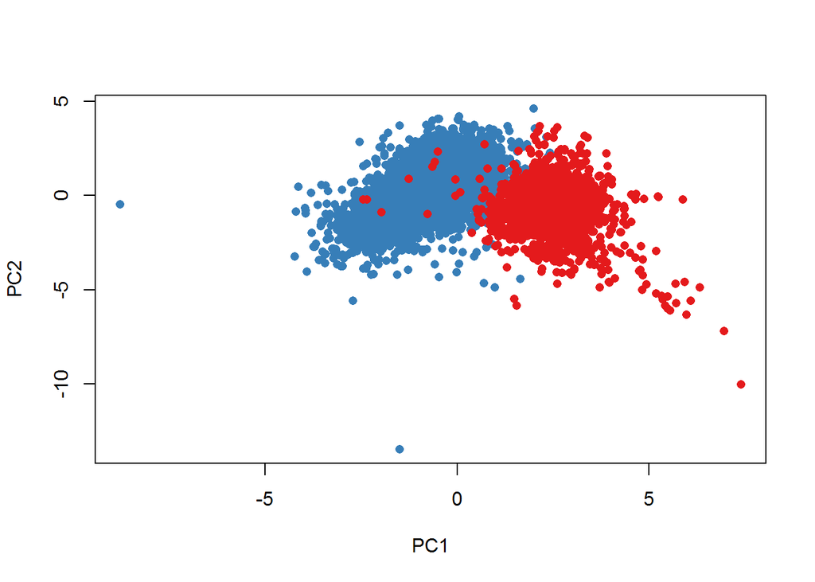

```r
RedWine1 <- RedWine
RedWine1$type <- 1
WhiteWine1 <- WhiteWine
WhiteWine1$type <- 2
WineDat <- rbind(WhiteWine,RedWine)
WineDat1 <- rbind(WhiteWine1,RedWine1)
WineDat <- subset( WineDat, select = -quality )
PCAscaled = prcomp(WineDat,scale = TRUE)
cols<-brewer.pal(n=3,name="Set1")
cols_t1<-cols[WineDat1$type]
plot(PCAscaled$x[,1:2],col = cols_t1, pch=16)
```

The above chart is a biplot for first two principal components, different colors indicating the wine types. It looks like there is clear association between the wine types with PCs. The data points with PC1>0 are of one wine type and the data points with PC1 < 0 are of another wine type except for few exceptions.

Below graph tries to plot the first two principal components with wine quality.

[figure not shown]

```r
cols_quality<-brewer.pal(n=3,name="Set1")
cols_quality_t1<-cols[WineDat1$quality]
plot(PCAscaled$x[,1:2],col = cols_quality_t1, pch=16)
```

# Model wine quality using principal components

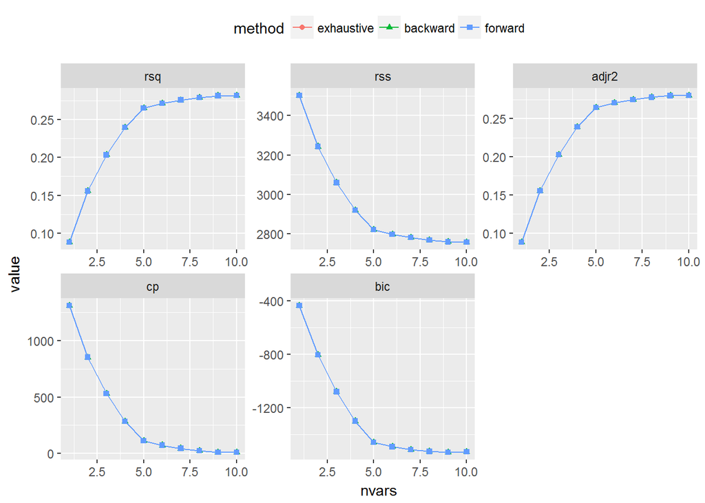

```r
WhiteWinePca <- subset(WhiteWine, select = -quality)
PCAscaledWhiteWine = prcomp(WhiteWinePca,scale = TRUE)
PCAscaledWhiteWine$x <- cbind(PCAscaledWhiteWine$x, quality = subset(WhiteWine, select = quality))
summaryMetrics <- NULL
whichAll <- list()

for ( myMthd in c("exhaustive", "backward", "forward") ) {
  rsRes <- regsubsets(quality~.,as.data.frame(PCAscaledWhiteWine$x),method=myMthd,nvmax=10)
  summRes <- summary(rsRes)
  whichAll[[myMthd]] <- summRes$which
  for ( metricName in c("rsq","rss","adjr2","cp","bic") ) {
    summaryMetrics <- rbind(summaryMetrics,
      data.frame(method=myMthd,metric=metricName,
                nvars=1:length(summRes[[metricName]]),
                value=summRes[[metricName]]))
  }
}
ggplot(summaryMetrics,aes(x=nvars,y=value,shape=method,colour=method)) + geom_path() + geom_point() + facet_wrap(~metric,scales="free") +   theme(legend.position="top")
```

Above graphs show the exhaustive, backward and forward methods performed for PCAs. The optimal number of variables in this case 5 as opposed to 7 variables in original fit. The values for Error, Adjusted R squared etc are comparable to the original fit indicating that same level of model fit can be obtained by less number of principal components.